# Module 3: Excel & Data Analytics (7.5 Hours)

From Raw Data to Business Insights

Author

Dr Aniruddha Bonnerjee

Abstract

Session 2: Learning some useful formulas for data analytics

# Session 2: Excel Formulas + Table Lookups

### Duration: 2 hours

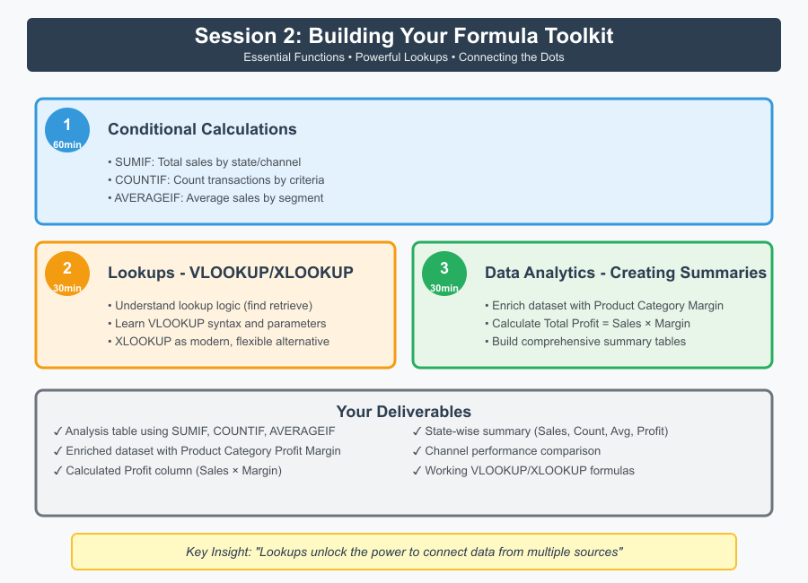

## Session Objective

**From cleaning the transition to data analytics.** By the end of this session, you will be able to: - Apply essential Excel functions (IF, SUMIF, COUNTIF, AVERAGEIF) to analyze data - Understand the logic and power of table lookups - Use VLOOKUP to retrieve data from reference tables - Use XLOOKUP as a modern, more flexible alternative - Enrich your dataset by combining data from multiple sources - Calculate derived metrics like profit margins - Build comprehensive summary analysis tables

## Why Formulas and Lookups Matter

In Session 1, you cleaned your data. But clean data alone doesn’t answer business questions. You need to: - **Calculate totals by category** (SUMIF) - **Count occurrences** (COUNTIF) - **Find averages** (AVERAGEIF) - **Connect related data** (VLOOKUP/XLOOKUP)

**Today’s mindset:** Transform from data cleaner to data analyst. You’re not just organizing information—you’re extracting insights.

## Today’s Data

### Primary Dataset

**Company Sales Performance Data** (cleaned from Session 1) - State, Month, Branch, Product Line - Sales, Sales Target, Channel, Segment - Transaction ID - ~1000 clean records (after removing duplicates and incomplete data).

The workbook now contains two data sheets - the original + clean data sheet.

### New: Product Master Table

Later in this session, we will be looking at a separate reference table (ProductMaster.xlsx) containing:

| Product Line | Product Code | Product Category | Profit Margin % |
| --- | --- | --- | --- |
| Electronics | ELEC-001 | Technology | 25% |
| Apparel | APRL-001 | Fashion | 40% |
| Home & Kitchen | HOME-001 | Home Essentials | 35% |
| Beauty & Personal Care | BEAU-001 | Personal Care | 45% |
| Sports & Fitness. | SPRT-001 | Sports & Outdoors | 30% |

**The challenge:** Your sales data has Product Line, but you need Product Category and Profit Margin. Lookups solve this!

## Part 1: Conditional Calculations (60 minutes)

In Part 1 we will begin the journey towards data analysis. For this we will be introducing some new functions. First we use the UNIQUE function to generate unique lists for State, Product Line, Sales Channel and Customer Segment. Next we will use the SUMIF (first) and AVERAGEIF (second) to derive sums and averages of Sales and Targets.

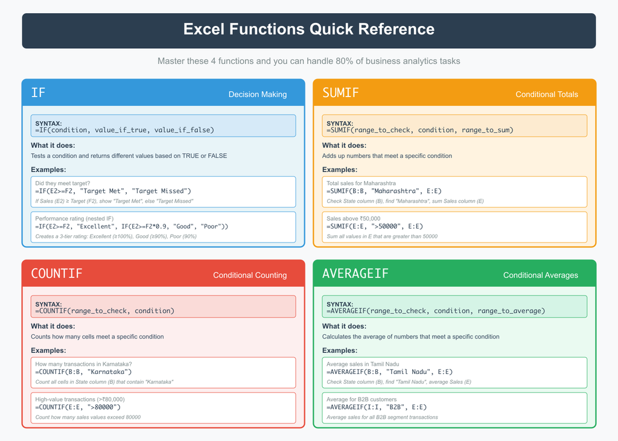

1. **First create a new sheet by clicking on the + icon to generate a new empty data sheet. Your workbook will now have three sheets: the original data, cleaned data and this new sheet you created.**
2. **Rename the new sheet Summary Analysis by right clicking on the sheet name in the bottom.**

### UNIQUE: Unique Values

**What it does:** Gives a list of UNIQUE values in a column.

**Syntax:**

```
=UNIQUE(range_to_check)
```

Go to cell A1 in the new summary analysis sheet. Type the following formula.

```
=UNIQUE('Clean Data'!B:.B)
```

**Tip**

Since State is also contained in Column B of Clean Data and it appears first, the column header is already typed out. You don’t need to enter it manually.

**Important**

**Note that since we are working in a new sheet, we must tell Excel where to find the cell references we want to use in our formula. In this case it is in Clean Data. Notice the pointer syntax carefully.**

### SUMIF: Conditional Totals

**What it does:** Adds up numbers that meet a specific condition.

**Syntax:**

```
=SUMIF(range_to_check, condition, range_to_sum)
```

**Mental Model:** “Look in this range, find cells matching this condition, then sum the corresponding values from another range.”

### Example 1: Total Sales & Targets by State

**Step 1: Create the structure by using SUMIF function.** We have already generated a list of States by using the UNIQUE function in A1. Type Total Sales in B1 and Total Target in C1. Then use the following SUMIF formula for Total Sales and Total Target Columns. Note, you only need to do it for the first occurrence and copy. The formulas are shown below:

| State (A1) | Total Sales (B1) | Total Target (C1) |
| --- | --- | --- |
| Karnataka (A2) | =SUMIF(‘Clean Data’!B:.B, A2, ‘Clean Data’!F:.F) | =SUMIF(‘Clean Data’!B:.B, A2, ‘Clean Data’!G:.G) |
| Tamil Nadu (A3) | =SUMIF(‘Clean Data’!B:.B, A3, ‘Clean Data’!F:.F) | =SUMIF(‘Clean Data’!B:.B, A3, ‘Clean Data’!G:.G) |
| Uttar Pradesh (A4) | =SUMIF(‘Clean Data’!B:.B, A4, ‘Clean Data’!F:.F) | =SUMIF(‘Clean Data’!B:.B, A4, ‘Clean Data’!G:.G) |
| Maharashtra (A5) | =SUMIF(‘Clean Data’!B:.B, A5, ‘Clean Data’!F:.F) | =SUMIF(‘Clean Data’!B:.B, A5, ‘Clean Data’!G:.G) |
| Rajasthan (A6) | =SUMIF(‘Clean Data’!B:.B, A6, ‘Clean Data’!F:.F) | =SUMIF(‘Clean Data’!B:.B, A6, ‘Clean Data’!G:.G) |
| West Bengal (A7) | =SUMIF(‘Clean Data’!B:.B, A7, ‘Clean Data’!F:.F) | =SUMIF(‘Clean Data’!B:.B, A7, ‘Clean Data’!G:.G) |
| Gujarat (A8) | =SUMIF(‘Clean Data’!B:.B, A8, ‘Clean Data’!F:.F) | =SUMIF(‘Clean Data’!B:.B, A8, ‘Clean Data’!G:.G) |
| Delhi (A9) | =SUMIF(‘Clean Data’!B:.B, A9, ‘Clean Data’!F:.F) | =SUMIF(‘Clean Data’!B:.B, A9, ‘Clean Data’!G:.G) |

**Tip**

Note the use of the . sign. This locks the column and prevents spill-overs. Many people also use the $ sign. For example instead of B:.B, use $B:$B as the column range in Excel. Both these ways allow you to write the formula once and copy it down. These are two different ways of ‘locking the columns’.

Explanation of the formulas:

```
=SUMIF('Clean Data'!B:.B,A2,'Clean Data'!F:.F)
```

**Translation:** - **‘Clean Data’!B:B** → Look in Clean Data sheet column B (State) - **value in A2 (State Value)**→ Find all A2 entries entries - ’**Clean Data’!F:.F**→ Sum corresponding values in Clean Data column F (Sales)

Now click on the cell containing the formula and double click on the small right hand side box. Total Sales for all the states will fill up.

- **Do the same for Target (it is contained in Column G of Clean Data).**

**Tip**

To format the table nicely, make the headers in ‘bold’ and in the Home Tab, select the ‘,’ formatting option which makes numbers easier to read.

The final results will look this:

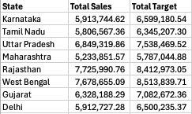

```
1. Which State has the highest sales? Which state has the lowest sales?
2. Which State has the highest target? Which state has the lowest target?
3. Bonus: How much of the total sales is explained by the top performing State?
```

### Example 2: Calculate Total Sales and Targets for each Product Line

**Step 1: Create a table structure first.**

Go to cell **A11.** This is an empty cell just under the State level data we summarized earlier. Use the UNIQUE formula to generate a list of Unique Product Lines contained in Column E of Clean Data.

```
=UNIQUE('Clean Data'!E:.E)
```

**Step 2: Create column headers for Total Sales and Total Target in B11 and C11.** In cell **C12 (next to Home & Kitchen)**, use the SUMIF formula to generate total sales and targets for each product line.

**Step 3:** Copy the formula to all product lines

**Step 4:** Format the table to make it look professional and readable

```
1. Note the Product Line with the highest sales.
2. What results can you conclude from this observation?
```

### COUNTIF: Conditional Counting

**What it does:** Counts how many cells meet a specific condition.

**Syntax:**

```
=COUNTIF(range_to_check, condition)
```

### Example 1: Transaction Count by State

Go back to the State level summary of sales and targets. Next to Target Totals create another column called Transactions - in **cell D1**. We will then calculate the total transactions for each state using the COUNTIF function.

**Formula:**

```
=COUNTIF('Clean Data'!B:.B, A2)
```

This formula tells Excel to go to ‘Clean Data’ and count all occurrences of the cell belonging to A2 (Karnataka). Drag this formula down for all States. Your expanded State summary table should now look like this:

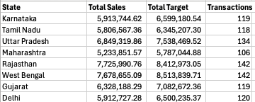

```
WORK IN PAIRS:
1. Which State has the highest number of transactions?
2. Which State has the lowest number of transactions?
3. What is the total number of transactions?
4. What is the proportion of transactions explained by each State
```

### Example 2: Repeat this for Product Line

The results should look like this:

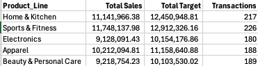

### Exercise for Business Insight:

#### For each State and Product Line calculate average Sales Per Transaction.

1. Create a new column for both State level data and Product Level Data named Sales Per Transaction.
2. Calculate Sales Per Transaction by dividing Total Sales by Transactions. For this you can use the formula =B2/D2 (for States) and copy down. For Product Lines you can use the formula = B12/D12 and copy down.
3. Your results should look like this. Notice we are beginning to expand our table to gain new business insights.

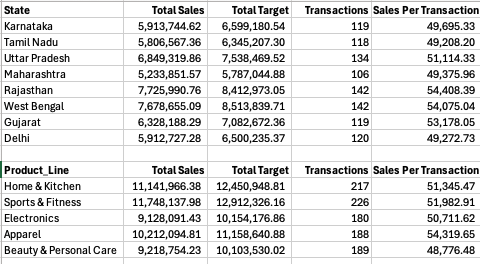

```
1. Which State and Product Line have the highest Sales Per Transaction.
2. What business insight can we infer from this?
```

### Example 3: How Many Transactions Met Target overall?

You created the Performance column in Part 1 using the IF function, where we assigned a value of 1 if Target was met and 0 otherwise. This data is in column L of Clean Data sheet. Go to cell A18 in the Summary Analysis Sheet and type Target Met to give it context. Next go to cell B18 (next to it) and type the formula below:

**Formula:**

```
=COUNTIF('Clean Data'!L:.L, 1)
```

This tells Excel to go to column L in sheet ‘Clean Data’ and count all occurrences of 1 (where sales has met target).

**Tip**

An alternative and clever way to do it would be just to sum the entries in Performance Column since they only consist of 0 and 1. **Formula:**

```
=SUM('Clean Data'!L:.L)
```

**In both cases the answer should be 243. What can we infer from this?**

```
Out of 1000 data rows, sales were met only for 243 rows (i.e, 24.3%).
Either sales performance needs to improve or the targets are unrealistic.
```

### Example 4: How Many Transactions Met Target in each State

Step 1: Go to cell F1 and type Target Met to give it a column heading.

Step 2: Use the SUMIF formula for each State to sum the values in Column L in the Clean Data Sheet. Type the following formula in cell F2 and drag down to other States.

**Formula:**

```
=SUMIF('Clean Data'!B:.B,A2,'Clean Data'!L:.L)
```

Your summary data should now look like this:

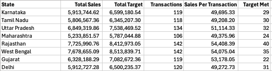

[output not shown]

### AVERAGEIF: Conditional Averages

**What it does:** Calculates the average of numbers that meet a specific condition.

**Syntax:**

```
=AVERAGEIF(range_to_check, condition, range_to_average)
```

### Example 1: Average Sales by Customer Segment

- Create a small table by first going to cell A20 and using the UNIQUE formula to generate the list of unique customer segments (contained in column I of Clean Data sheet). You will see 3 Customer Segments Listed

**Syntax:**

```
=UNIQUE('Clean Data'!I:.I)
```

- Type the header Average Sales in Cell B20. Then in Cell B21 use the AVERAGEIF formula shown below and copy the formula to all Customer Segments.

```
=AVERAGEIF('Clean Data'!I:.I,A21,'Clean Data'!F:.F)
```

**Business Question:** Which customer segment has the highest average sales?

### Example 2: Compare Average Sales across Channels

**Business Question:** Which Sales Channel has the highest average sales?

### Practice Exercises (Optional at home)

Create these summary tables on your own:

1. **Product Line Performance**
   - Total Sales by Product Line
   - Transaction Count
   - Average Sale
2. **Channel Performance**
   - Total Sales by Channel
   - Transaction Count
   - Average Sale
3. **Customer Segment Analysis**
   - Total Sales by Segment
   - Transaction Count
   - Average Sale

## Part 2: Introduction to Table Lookups (30 minutes)

### The Problem Lookups Solve

Your sales data has **Product Line**, but you need: - Product Category - Profit Margin %

This information exists in a separate **Product Master** table.

### Understanding Lookup Logic

**Analogy: Phone Directory**

You have: Person’s name  
You want: Their phone number  
You do: Look up name in directory, retrieve corresponding number

**In Excel:**

You have: Product Line (e.g., “Electronics”)  
You want: Profit Margin % (e.g., 25%) or Product Category (e.g, Technology)  
You do: Look up “Electronics” in Product Master, retrieve corresponding Profit Margin

### VLOOKUP Syntax

```
=VLOOKUP(lookup_value, table_array, col_index_num, [range_lookup])
```

**Parameters explained:**

1. **lookup_value**: What you’re searching for
   - Example: E2 (cell containing “Sports & Fitness”)
2. **table_array**: Where to search
   - Example: ProductMaster!$A$1:$D$6 (the entire Product Master table)
3. **col_index_num**: Which column to return (counting from left)
   - Column 1 = Product Line
   - Column 2 = Product Code
   - Column 3 = **Product Category ← We want this!**
   - Column 4 = Profit Margin %
4. **range_lookup**: FALSE for exact match
   - **Always use FALSE for business data!**
   - TRUE is for approximate matches (rarely used)

**Caution**

Remember to use $ signs in your lookup reference otherwise you will run into a spill error.

### Product Master Table Structure

Let’s visualize this clearly. Open the Excel file ProductMaster.xlsx. You will see the following data. It contains a few rows and columns, some of which are not present in our original data file. Our goal is to add some information from here to our Clean Data Sheet.

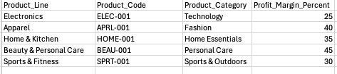

### Example 1: Retrieve Product Category

**Goal:** Add a “Product_Category” column to your sales data

**Step 1: Insert a new column** - Go to column O and in cell O1 type Product Category. We will next use VLOOKUP to retrieve the Product Category from the Excel file ProductMaster.xlsx. Note that Product_Category is in **column 3** in product_master_table worksheet.

**Step 2: Write the VLOOKUP formula in O2.**

Product_Line is in column E in the original data file (Clean Data worksheet):

```
=VLOOKUP(E2,[ProductMaster.xlsx]product_master_table!$A$1:$D$6,3, FALSE)
```

**Step 3: Understand each part** - `E2` → Look for this value (the Product Line in current row) -[ProductMaster.xlsx]product_master_table → Search in this file (ProductMaster) and in the worksheet product_master_table, using columns from $A$2:$D$6 - `3` → Return value from 3rd column (Product_Category) - `FALSE` → Exact match only

**Step 4: Copy down** - Double-click fill handle to copy formula to all rows

**Result:** If D2 = “Electronics”, the formula returns “Technology”

### Example 2: Retrieve Profit Margin

**Goal:** Add a “Profit Margin” column by going to Column P in Clean Data and type it in the header (P1). In P2 type the following formula:

**Formula:**

```
=VLOOKUP(E2,[ProductMaster.xlsx]product_master_table!$A$1:$D$6, 4, FALSE)
```

**Breakdown:** - Same lookup value (E2) and product_master_table - `4` → Return value from 4th column (Profit_Margin_%) - Result: If E2 = “Sports & Fitness”, returns 30.

### Why Use $ Signs (Absolute References)?

The `$` signs lock the table range when you copy the formula down:

**Without $ signs:** - Row 2: Looks in A:D ✓ - Row 3: Looks in A:D shifted down ✗ (wrong!)

**With $ signs:** - Row 2: Looks in $A:$D ✓ - Row 3: Still looks in $A:$D ✓ (correct!) - Row 100: Still looks in $A:$D ✓ (correct!)

**Rule of thumb:** Always use $ for the table_array in VLOOKUP.

### Testing Your VLOOKUP

After creating your VLOOKUP formulas, verify they work:

1. **Pick a specific row** (e.g., row 10)
2. **Note the Product_Line** (e.g., “Apparel”)
3. **Check the Product Master table** - What should Apparel return?
   - Product_Category: “Fashion”
   - Profit_Margin_%: 40
4. **Check your formula result** - Does it match?

Do this for 3-4 rows to ensure accuracy!

### XLOOKUP - Modern Approach

### Why XLOOKUP is Better Than VLOOKUP

VLOOKUP has limitations: 1. **Can only look to the right** - Column order matters, so **Product Line HAS to be the FIRST column** of the lookup table 2. **Hard-to-read syntax** - Column counting is manual and error-prone 3. **No built-in error handling** 4. **Table must be sorted** for approximate matches

**XLOOKUP** (available in Excel 365/2021+) fixes all of this!

### XLOOKUP Syntax

```
=XLOOKUP(lookup_value, lookup_array, return_array, [if_not_found])
```

**Much simpler! Only 3-4 parameters instead of 4!**

1. **lookup_value**: What you’re searching for
2. **lookup_array**: Where to search (just one column!)
3. **return_array**: What to return (just one column!)
4. **if_not_found**: (Optional) What to show if not found

### Example 1: Retrieve Product Category with XLOOKUP

**Formula:**

```
=XLOOKUP(E2, [ProductMaster.xlsx]product_master_table!$A$1:$A$6, [ProductMaster.xlsx]product_master_table!$C$1:$C$6, "Not Found")
```

**Translation:** - Look for value in E2 (e.g., “Electronics”) - Search in column A of ProductMaster (Product_Line column) - Return corresponding value from column C (Product_Category) - If not found, display “Not Found”

**XLOOKUP advantages:** - ✓ Clearer (no column counting!) - ✓ Built-in error handling - ✓ Can look left or right (order doesn’t matter!)

### Example 2: Retrieve Profit Margin with XLOOKUP

**Formula:**

```
=XLOOKUP(E2, [ProductMaster.xlsx]product_master_table!$A$1:$A$6, [ProductMaster.xlsx]product_master_table!$D$1:$D$6, "Not Found")
```

**Translation:** - Look for value in E2 - Search in column A (Product_Line) - Return value from column D (Profit_Margin_%) - If not found, return “Not Found”

## Part 3: Data Analytics (30 minutes)

## Enrich Dataset & Summarize Findings

## Step 1: Calculate Total Profit

Now the magic happens! You can calculate profit for each transaction.

Profit_Margin is in column P:

```
=F2 * (P2 / 100)
```

**Example:** - Sales (F2) = ₹50,000 - Profit_Margin (P2) = 25% - Total_Profit = 50,000 × (25/100) = ₹12,500

**Copy this formula down for all rows!**

### Step 4: Verify Your Enriched Dataset

You should now have these NEW columns: 1. ✓ Product_Category (from lookup) 2. ✓ Profit_Margin (from lookup) 3. ✓ Total_Profit (calculated)

Plus the columns you created in Part 1: 4. ✓ Performance 5. ✓ Performance_Rating 6. ✓ High Value + Flags for data problems

**Note**

**Your dataset is now ENRICHED** with valuable derived information! We have moved from cleaning to analytics!

## Build Summary Analysis

### Comprehensive Analysis

**Guided Exercises: Create a comprehensive table for:**

- States with Total Sales, Total Target, # of Transactions, Sales Per Transaction, # of Transactions that met Target, Total Profits, Profit Margin and % of transactions that met Target. Note that you have already done most of this table in earlier exercises. Your results should resemble the following table.

**Tip**

You would have used the following formulas: UNIQUE, SUMIF. Note that in this table the averages are derived by dividing the totals by number of transactions.

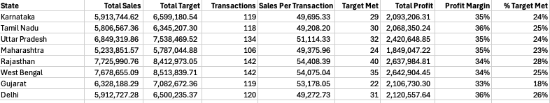

Which State has the highest and lowest Total Profits? Which State has the highest Profit Margin?

- Repeat the same analysis for Product Line. Which Product Line brings in the most profits? Which product line has the highest % of targets met?

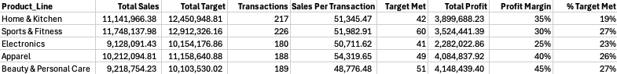

- For Customer Segment & Sales Channel create the following tables.

**Tip**

Here we use the following formula UNIQUE, AVERAGEIF, SUMIF. Note that we can get to the totals by multiplying the averages by the number of transactions.

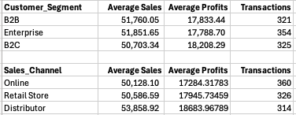

- Which Customer Segment has the highest sales? Which Customer Segment has the highest profits? What did you notice?
- Answer the same questions for Sales Channel.

## Your Deliverables Checklist

By the end of this session, you should have:

### ✓ Enriched Dataset

Your main dataset now includes: 1. Product Category (from VLOOKUP/XLOOKUP) 2. Profit_Margin_% (from VLOOKUP/XLOOKUP) 3. Total Profit (calculated: Sales × Margin%) 4. Performance flags (from IF functions) 5. Transaction_Size categories

### ✓ Summary Analysis Tables

You should have created at least 4 summary tables with Analysis

### ✓ Working Formulas

Demonstrate understanding of: - IF (simple and nested) - UNIQUE - SUMIF - COUNTIF - AVERAGEIF - VLOOKUP or XLOOKUP

## Common Mistakes to Avoid

❌ **Forgetting $ signs in lookup table references** - Bad: `=VLOOKUP(D2, ProductMaster!A:D, 3, FALSE)` - Good: `=VLOOKUP(D2, ProductMaster!$A:$D, 3, FALSE)`

❌ **Using hard-coded values instead of cell references** - Bad: `=SUMIF(B:B, "Maharashtra", E:E)` (what if you want to change the state?) - Better: `=SUMIF($B:$B, A2, $E:$E)` (flexible, reusable)

❌ **Mixing up column numbers in VLOOKUP** - Count carefully! Column A=1, B=2, C=3, D=4

❌ **Not verifying formulas before copying** - Always test on first row before copying to 1000 rows!

## Key Takeaways

✓ **Conditional functions (SUMIF, COUNTIF, AVERAGEIF) turn raw data into insights** - They’re your bread and butter for analysis

✓ **Lookups connect related data** - VLOOKUP/XLOOKUP let you combine information from multiple sources

✓ **One dataset + Reference tables = Enriched analysis** - This is how professional analysts work

✓ **Formula mastery = Efficiency** - Write once, copy thousands of times

✓ **Always test your formulas** - Check a few rows manually before trusting them

✓ **XLOOKUP is the future** - If you have it, use it! If not, VLOOKUP still works great

## What’s Next?

**Session 3: Mastering Pivot Tables**

Now that your data is clean AND enriched with calculated fields, you’ll learn to: - Build pivot tables that summarize thousands of rows instantly - Create multi-dimensional analysis (State × Product, Channel × Segment) - Use calculated fields within pivots - Extract business insights from patterns - Answer complex business questions in seconds

**Note**

**The power multiplier:** Clean data + Enriched fields + Pivot tables = Executive-ready insights

## Questions to Reflect On

Before next session, think about:

1. How much time would these formulas save vs manual calculation?

*Module 3: Excel & Data Analytics | Session 2 of 4*